# CSCI E-63C Week 7 midterm exam

### 5-fold, 10-fold cross validation on white dataset

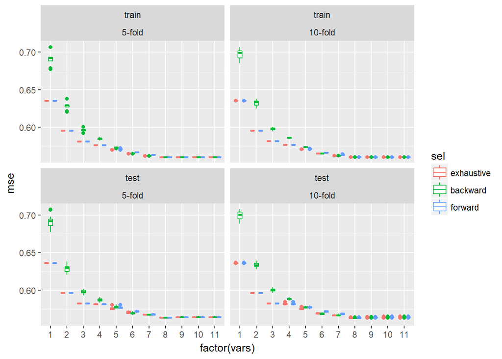

```r
# plot MSEs by training/test, number of variables, reduce nTries to 20 in interest of expediency, and only 5/10 folds
dfTmpWhite <- rbind(data.frame(xvalMSEregsubsetsWine(data=white, nTries=20, kXval=5), xval="5-fold"),
              data.frame(xvalMSEregsubsetsWine(data=white, nTries=20, kXval=10), xval="10-fold"))
ggplot(dfTmpWhite,aes(x=factor(vars),y=mse,colour=sel)) + geom_boxplot()+facet_wrap(~trainTest+xval)
```

```r
# for viz testing, runs quickly:
#ggplot(data.frame(xvalMSEregsubsetsWine(data=white, 10 ,kXval=2), xval="2-fold"),
#       aes(x=factor(vars),y=mse,colour=sel)) + geom_boxplot()+facet_wrap(~trainTest+xval)
```

Reviewing above outputs I feel the plots above are too squashed for ready eyeball appraisal and since nvar=1 has the highest MSE by far in both datsets (which of course is the root of the problem), I’m going to regenerate those initial plots with versions that only display nvar=2 through nvar=11 so that the y scale is narrower. First `red` and then `white`.  
**NOTE:** The plot zooming winds up not having a large effect for either dataset but results are marginally more interpretable than they had been, so those are what I’ll analyze.

### 5-fold, 10-fold cross validation on red dataset, nvar > 1

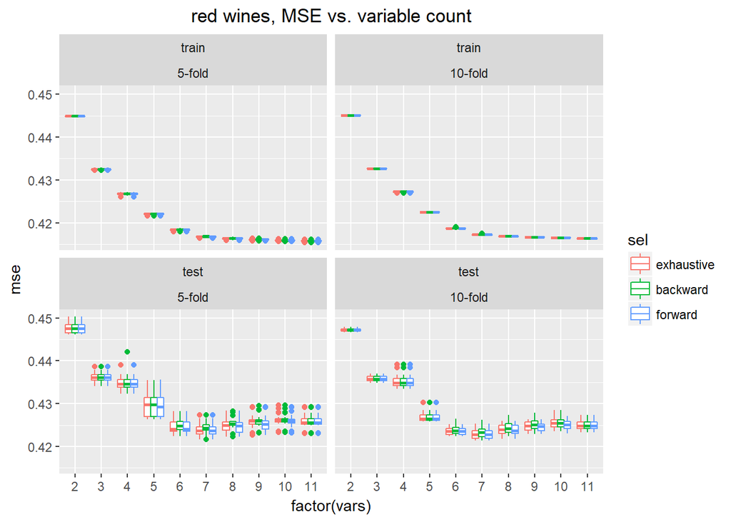

```r
# plot MSEs by training/test, number of variables, reduce nTries to 20 in interest of expediency, and only 5/10 folds
# cut out "number of vars = 1" from the display
ggplot(dfTmpRed[which(dfTmpRed$vars!=1),] ,aes(x=factor(vars),y=mse,colour=sel)) + geom_boxplot()+facet_wrap(~trainTest+xval) + ggtitle('red wines, MSE vs. variable count') + theme(plot.title = element_text(hjust = 0.5))
```

> Compare and comment on the number of variables deemed optimal by resampling versus those selected by `regsubsets` in the previous task.

Reviewing above:

- for 5-fold the lowest test MSE is at either nvar=6 or nvar=7
  - nvar=6, all 3 methods show low MSE, would need to look at raw numbers to compare vs. nvar=7 to see if lowest average across all three
  - nvar=7, mean test MSE for `backwards`, in green, increases a bit vs. nvar=6 and the other two methods appear to be unchanged. In the run I’m looking at for this text it looks like there could be a single outlier for `backwards`, pulling the mean MSE up a bit
- 10-fold, nvar=7 definitely appears to produce lowest mean test MSE
  - `backwards` results at nvar=7 are higher than the other two methods but still lower than same method at nvar=6 (or, of course, nvar=8)
- in Problem 2 the diagnostic plots for `red` had, aside from `bic` indicated n=7 was optimal (`bic` plot for all search methods indicated nvar=6 was best).

On to `white`, similar approach to zoom in on the data by skipping nvar=1.

### 5-fold, 10-fold cross validation on white dataset, nvar > 1

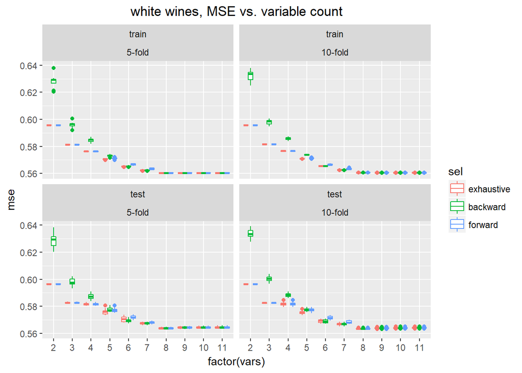

```r
# cut out "number of vars = 1" from the display
ggplot(dfTmpWhite[which(dfTmpWhite$vars!=1),] ,aes(x=factor(vars),y=mse,colour=sel)) + geom_boxplot() + facet_wrap(~trainTest+xval) + ggtitle('white wines, MSE vs. variable count') + theme(plot.title = element_text(hjust = 0.5))
```

Reviewing `white` MSE plots:

- much more straightforward than `red` - both 5-fold and 10-fold cross-validation say nvar=8 produces lowest mean test MSE
- with 10-fold the improvement vs. nvar=9 isn’t as evident as it is with 5-fold, but it is still present
- in Problem 2 the `white` diagnostic plots selected 8 as the best variable count, so again this dataset produces more consisten results than was happening with `red`

> Compare resulting models built separately for red and white wine data.

For `red`, favor I think nvar=7 winds up being the optimal model while for `white` the answer is even more clear cut at best variable count = 8.

Run some R to print out what those low mean test MES values are, both at 5-fold and 10-fold.  
First `red`:

```r
test_mse_n7_5f_mean_red = filter(dfTmpRed, trainTest=='test', vars==7, xval=='5-fold') %>%
  dplyr::select(mse) %>%
  summarize(mean_mse = mean(mse, na.rm = TRUE))
test_mse_n7_10f_mean_red = filter(dfTmpRed, trainTest=='test', vars==7, xval=='10-fold') %>%
  dplyr::select(mse) %>%
  summarize(mean_mse = mean(mse, na.rm = TRUE))
print(paste0('red wines, nvar=7, 5-fold mean test MSE ', test_mse_n7_5f_mean_red, ' and 10-fold ', test_mse_n7_10f_mean_red))
```

```
## [1] "red wines, nvar=7, 5-fold mean test MSE 0.424126755147318 and 10-fold 0.423029827384175"
```

And `white`:

```r
test_mse_n8_5f_mean_white = filter(dfTmpWhite, trainTest=='test', vars==8, xval=='5-fold') %>%
  dplyr::select(mse) %>%
  summarize(mean_mse = mean(mse, na.rm = TRUE))
test_mse_n8_10f_mean_white = filter(dfTmpWhite, trainTest=='test', vars==8, xval=='10-fold') %>%
  dplyr::select(mse) %>%
  summarize(mean_mse = mean(mse, na.rm = TRUE))
print(paste0('white wines, nvar=8, 5-fold mean test MSE ', test_mse_n8_5f_mean_white, ' and 10-fold ', test_mse_n8_10f_mean_white))
```

```
## [1] "white wines, nvar=8, 5-fold mean test MSE 0.563806795794122 and 10-fold 0.563488052333515"
```

More data (more observations) for `white` dataset does not result in lower test MSE vs. `red`, but one imagines it would be even higher if there weren’t as many rows as there are, i.e. if the observation count were reduced to what was provided in the `red` dataset.

# Sub-problem 4: lasso/ridge (25 points)

Use regularized approaches (i.e. lasso and ridge) to model quality of red and white wine (separately). Compare resulting models (in terms of number of variables and their effects) to those selected in the previous two tasks (by `regsubsets` and resampling), comment on differences and similarities among them.

> Use regularized approaches (i.e. lasso and ridge) to model quality of red and white wine (separately).

I’ll create lasso and ridge models on `red` and discuss, followed by same pattern for `white`.

### lasso, red

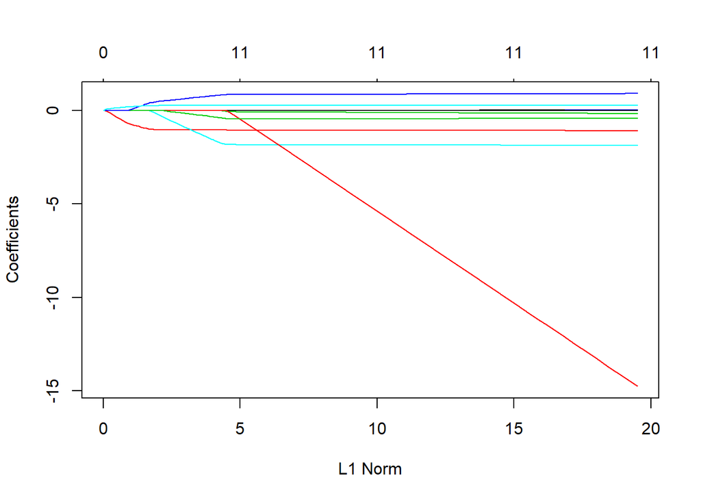

```r
# -1 to get rid of intercept that glmnet knows to include:
x_red = model.matrix(y_quality~., red)[,-1]
y_red = red[,'y_quality']
lasso_fit_red = glmnet(x_red, y_red, alpha=1)
plot(lasso_fit_red)
```

Note that regularization increases from right to left - as shrinkage increases more coefficients become zero - associated variables are dropped from the model. Peeking at a head on `lasso_fit_red` seems to indicate `density` is represented by the red diagonal line, which rapidly loses relative weight as $\lambda$ increases and more regularization occurs. During that period while coefficient for `density` is lessening (technically the value is increasing at it starts with a relatively large negative value and moves toward 0), which is the right 3/4 of above plot, nvar remains at 11. Then once `density` zeroes out the remaining variables appear to converge on zero relatively rapidly - but that is at least partially an artifact of using default $\lambda$ values.

By submitting a custom range of $\lambda$ values we can get a more clear cut picture on when, and at which nvar count, the coefficients for certain variables head toward zero.

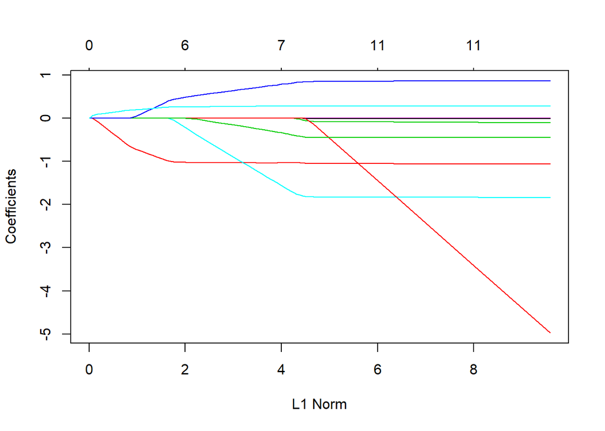

```r
rng = 10^((-50:10)/20)
lasso_fit_red2 = glmnet(x_red, y_red, alpha=1, lambda=rng)
plot(lasso_fit_red2)
```

Next is the output of `cv.glmnet`, showing averages and variation in MSE values under cross-validation for select values of $\lambda$ (X axis is the log of the input $\lambda$ value):

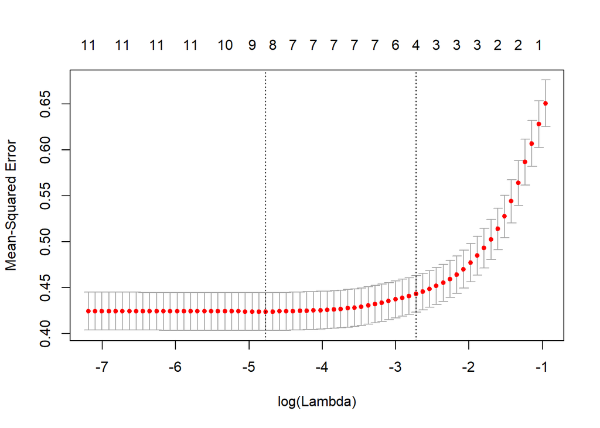

```r
cv_lasso_fit_red = cv.glmnet(x_red, y_red, alpha=1)
plot(cv_lasso_fit_red)
```

The two vertical lines in the plot above indicate $\lambda$ that results in minimum cross-validation MSE, far left, and $\lambda$ that is one standard error away, dashed line to the right of middle. Details on those two MSE/$\lambda$ combinations are printed out below.

```r
lowest_mse_lambda_red = cv_lasso_fit_red$lambda.min
print(paste0('lambda producing lowest MSE for red wines/lasso: ', lowest_mse_lambda_red))
```

```
## [1] "lambda producing lowest MSE for red wines/lasso: 0.00847689985341286"
```

```r
print(paste0('log of same value, used for X axis in chart: ', log(lowest_mse_lambda_red)))
```

```
## [1] "log of same value, used for X axis in chart: -4.77041047934416"
```

```r
predict(lasso_fit_red, type="coefficients", s=lowest_mse_lambda_red)
```

```
## 12 x 1 sparse Matrix of class "dgCMatrix"
##                                 1
## (Intercept)           4.162837203
## fixed_acidity         .
## volatile_acidity     -1.024302103
## citric_acid           .
## residual_sugar        0.001338421
## chlorides            -1.709310471
## free_sulfur_dioxide   0.002439166
## total_sulfur_dioxide -0.002673964
## density               .
## pH                   -0.382460651
## sulphates             0.819613626
## alcohol               0.285179090
```

```r
lowest_mse_plus_one_sd_lambda_red = cv_lasso_fit_red$lambda.1se
print(paste0('lambda producing MSE 1SD away from min, for red wines/lasso: ', lowest_mse_plus_one_sd_lambda_red))
```

```
## [1] "lambda producing MSE 1SD away from min, for red wines/lasso: 0.0656335569822254"
```

```r
print(paste0('log of same value, used for X axis in chart: ', log(lowest_mse_plus_one_sd_lambda_red)))
```

```
## [1] "log of same value, used for X axis in chart: -2.72366817446056"
```

```r
predict(lasso_fit_red, type="coefficients", s=lowest_mse_plus_one_sd_lambda_red)
```

```
## 12 x 1 sparse Matrix of class "dgCMatrix"
##                                  1
## (Intercept)           3.2432352603
## fixed_acidity         .
## volatile_acidity     -0.9813609248
## citric_acid           .
## residual_sugar        .
## chlorides             .
## free_sulfur_dioxide   .
## total_sulfur_dioxide -0.0005165181
## density               .
## pH                    .
## sulphates             0.3930852016
## alcohol               0.2567463205
```

Next, going to use resampling and train/test splits in order to get true test MSE for lasso model, and also see if the same variables are being dropped on different samples of the data.

```r
lasso_sampling = function(x, y, try_count) {
  lassoCoefCnt = 0
  lassoMSE = NULL
  for ( iTry in 1:try_count ) {
    bTrain = sample(rep(c(TRUE,FALSE),length.out=dim(x)[1]))
    cvLassoTrain = cv.glmnet(x[bTrain,],y[bTrain],alpha=1,lambda=10^((-120:0)/20))
    lassoTrain = glmnet(x[bTrain,],y[bTrain],alpha=1,lambda=10^((-120:0)/20))
    lassoTrainCoef = predict(lassoTrain,type="coefficients",s=cvLassoTrain$lambda.1se)
    lassoCoefCnt = lassoCoefCnt + (lassoTrainCoef[-1,1]!=0)
    lassoTestPred = predict(lassoTrain,newx=x[!bTrain,],s=cvLassoTrain$lambda.1se)
    lassoMSE = c(lassoMSE,mean((lassoTestPred-y[!bTrain])^2))
  }

  #resampling_mse = mean(lassoMSE) # avg test MSE, over 30 train/test splits
  #lassoCoefCnt  # frequency of inclusion of each of the coefficients in the model
  out = list(mean(lassoMSE), lassoCoefCnt)
  return (out)
}

try_count=30
lasso_sampling_results_red = lasso_sampling(x_red, y_red, try_count=try_count)
resampling_mse_red = lasso_sampling_results_red[[1]]
lasso_coef_cnt_red = lasso_sampling_results_red[[2]]

print(paste0('MSE resampling, lasso: ', resampling_mse_red)) #around 0.44
```

```
## [1] "MSE resampling, lasso: 0.445924307310481"
```

```r
print(sprintf('Coefficient counts, across %d resample rounds:', try_count))
```

```
## [1] "Coefficient counts, across 30 resample rounds:"
```

```r
lasso_coef_cnt_red
```

```
##        fixed_acidity     volatile_acidity          citric_acid
##                   10                   30                    0
##       residual_sugar            chlorides  free_sulfur_dioxide
##                    1                    8                    0
## total_sulfur_dioxide              density                   pH
##                   20                    0                    4
##            sulphates              alcohol
##                   30                   30
```

The MSE produced by above, 0.4459243, is just a little bit higher than that returned by cross-validation in **Sub-problem 3**, 0.4230298 (close enough that on any given run of this .Rmd that it could be a little bit lower instead?).

After lasso on `red` dataset, the next section will run through ridge regression on same.

### ridge, red wine

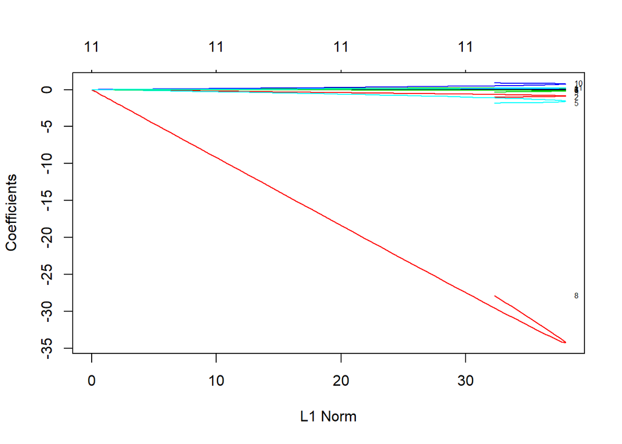

```r
ridge_fit_red = glmnet(x_red, y_red, alpha=0)
plot(ridge_fit_red, label=TRUE) #, ylim=c(5,-5))
```

Looks rather familiar overall, with pesky `density` still causing trouble with graph readability. The non-`density` variables at the top all seem to converge towards zero at about the same rate, hard to tell. Of course this being ridge regression they never actually reach zero and we can see on the top X axis that variable count remains constant at 11.

Below may be not be a realistic representation of the model above as I’ve just kicked out `density` (adjusting `ylim` didn’t help out and I don’t know how to suppress `density` in the `glmnet` output such tha the plot would skip it), but it looks to be a feasible close up of how the other 10 variables approach zero as regularization increases. The coefficients on these variables generally shrink in a similar gradual manner, except for `3`, which starts out negative and swings to be increasingly positive (though still very small) before beginning its descent toward zero.

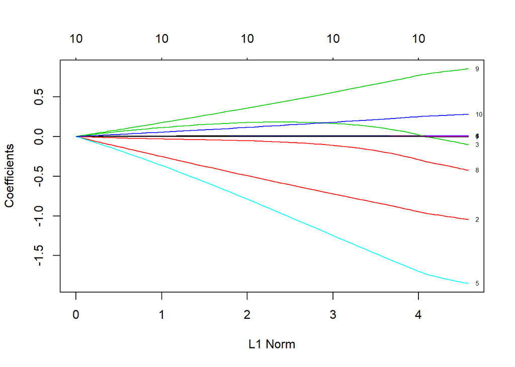

```r
ridge_fit_red_10var = glmnet(subset(x_red, select=-density), y_red, alpha=0)
plot(ridge_fit_red_10var, label=TRUE)
```

Run a `cv.glmnet` to perform cross-validation on the ridge regression model in order to choose optimal $\lambda$

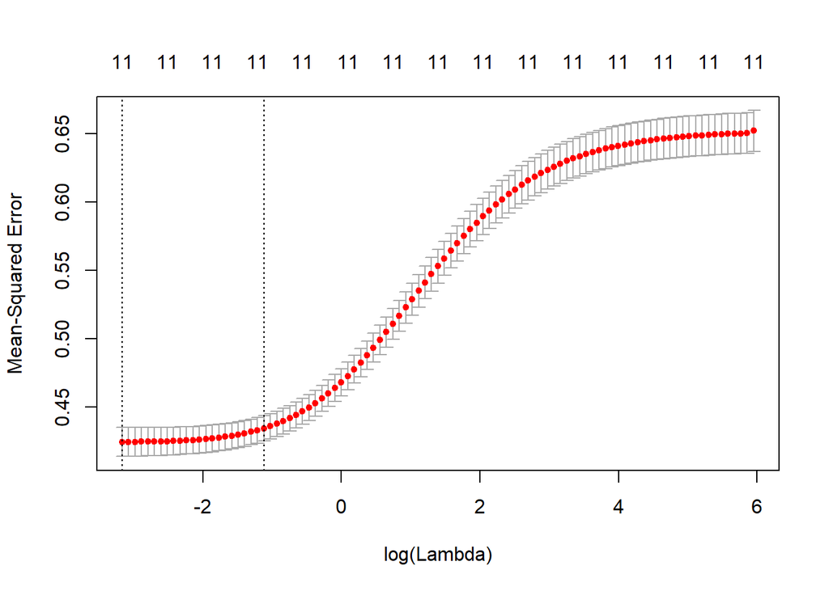

```r
cv_ridge_fit_red = cv.glmnet(x_red, y_red, alpha=0)
plot(cv_ridge_fit_red)
```

```r
lowest_mse_lambda_ridge_red = cv_ridge_fit_red$lambda.min
print(paste0('lambda producing lowest MSE for red wines/ridge: ', lowest_mse_lambda_ridge_red))
```

```
## [1] "lambda producing lowest MSE for red wines/ridge: 0.0421897303229193"
```

```r
p_lowest_mse_predict_ridge_red = predict(cv_ridge_fit_red, type="coefficients", s=lowest_mse_lambda_ridge_red)
p_lowest_mse_predict_ridge_red
```

```
## 12 x 1 sparse Matrix of class "dgCMatrix"
##                                  1
## (Intercept)           32.195393748
## fixed_acidity          0.030719026
## volatile_acidity      -1.014093629
## citric_acid           -0.081792026
## residual_sugar         0.019196679
## chlorides             -1.808348147
## free_sulfur_dioxide    0.003682235
## total_sulfur_dioxide  -0.003075532
## density              -28.359385592
## pH                    -0.307592837
## sulphates              0.885782191
## alcohol                0.253189853
```

```r
print('min MSE, variables absolute weighting, high to low:')
```

```
## [1] "min MSE, variables absolute weighting, high to low:"
```

```r
sort(abs(p_lowest_mse_predict_ridge_red[-1,1]), decreasing=TRUE)
```

```
##              density            chlorides     volatile_acidity
##         28.359385592          1.808348147          1.014093629
##            sulphates                   pH              alcohol
##          0.885782191          0.307592837          0.253189853
##          citric_acid        fixed_acidity       residual_sugar
##          0.081792026          0.030719026          0.019196679
##  free_sulfur_dioxide total_sulfur_dioxide
##          0.003682235          0.003075532
```

`free_sulfur_dioxide` and `total_sulfur_dioxide` have very low coefficients, not far from zero. In fact the last 5 listed above are pretty low.

```r
lowest_mse_plus_one_sd_lambda_ridge_red = cv_ridge_fit_red$lambda.1se
print(paste0('lambda producing MSE 1SD away from min, for red wines/lasso: ', lowest_mse_plus_one_sd_lambda_ridge_red))
```

```
## [1] "lambda producing MSE 1SD away from min, for red wines/lasso: 0.326659759711471"
```

```r
p_lowest_mse_1sd_predict_ridge_red = predict(cv_ridge_fit_red, type="coefficients", s=lowest_mse_plus_one_sd_lambda_ridge_red)
p_lowest_mse_1sd_predict_ridge_red
```

```
## 12 x 1 sparse Matrix of class "dgCMatrix"
##                                  1
## (Intercept)           37.604951328
## fixed_acidity          0.024606733
## volatile_acidity      -0.794280618
## citric_acid            0.155614909
## residual_sugar         0.015055250
## chlorides             -1.419152780
## free_sulfur_dioxide    0.001437321
## total_sulfur_dioxide  -0.002290627
## density              -33.715783770
## pH                    -0.141086544
## sulphates              0.679389870
## alcohol                0.191793485
```

```r
print('1 SD away, variables absolute weighting, high to low:')
```

```
## [1] "1 SD away, variables absolute weighting, high to low:"
```

```r
sort(abs(p_lowest_mse_1sd_predict_ridge_red[-1,1]), decreasing=TRUE)
```

```
##              density            chlorides     volatile_acidity
##         33.715783770          1.419152780          0.794280618
##            sulphates              alcohol          citric_acid
##          0.679389870          0.191793485          0.155614909
##                   pH        fixed_acidity       residual_sugar
##          0.141086544          0.024606733          0.015055250
## total_sulfur_dioxide  free_sulfur_dioxide
##          0.002290627          0.001437321
```

Similar to “lowest MSE” weighting, which shouldn’t be surprising, but most coefficients are closer to zero. Makes sense I think, model with this lambda should be less flexible.

```r
ridge_sampling = function(x, y, try_count) {
    ridgeCoefCnt = 0
    ridgeCoefAve = 0
    ridgeMSE = NULL
    for ( iTry in 1:30 ) {
      bTrain = sample(rep(c(TRUE,FALSE),length.out=nrow(x)))
      cvridgeTrain = cv.glmnet(x[bTrain,],y[bTrain],alpha=0,lambda=10^((-50:50)/20))
      ridgeTrain = glmnet(x[bTrain,],y[bTrain],alpha=0,lambda=10^((-50:50)/20))
      ridgeTrainCoef = predict(ridgeTrain,type="coefficients",s=cvridgeTrain$lambda.1se)
      ridgeCoefCnt = ridgeCoefCnt + (ridgeTrainCoef[-1,1]!=0)
      ridgeCoefAve = ridgeCoefAve + ridgeTrainCoef[-1,1]
      ridgeTestPred = predict(ridgeTrain,newx=x[!bTrain,],s=cvridgeTrain$lambda.1se)
      ridgeMSE = c(ridgeMSE,mean((ridgeTestPred-y[!bTrain])^2))
    }
    ridgeCoefAve = ridgeCoefAve / length(ridgeMSE)
    out = list(mean(ridgeMSE), ridgeCoefAve)
    return (out)
}

try_count = 30
ridge_sampling_results_red = ridge_sampling(x_red, y_red, try_count=try_count)
ridge_resampling_mse_red = ridge_sampling_results_red[[1]]
ridge_coef_cnt_red = ridge_sampling_results_red[[2]]

print(paste0('MSE resampling, ridge: ', ridge_resampling_mse_red))
```

```
## [1] "MSE resampling, ridge: 0.451374338856102"
```

```r
print(sprintf('Coefficient counts, across %d resample rounds:', try_count))
```

```
## [1] "Coefficient counts, across 30 resample rounds:"
```

```r
ridge_coef_cnt_red
```

```
##        fixed_acidity     volatile_acidity          citric_acid
##          0.021055629         -0.693764466          0.183598847
##       residual_sugar            chlorides  free_sulfur_dioxide
##          0.008983494         -1.169120788          0.001048206
## total_sulfur_dioxide              density                   pH
##         -0.001882728        -30.663245754         -0.094519283
##            sulphates              alcohol
##          0.599417093          0.163525366
```

Now switch to regularization and subset selection on the `white` dataset.

### lasso, white

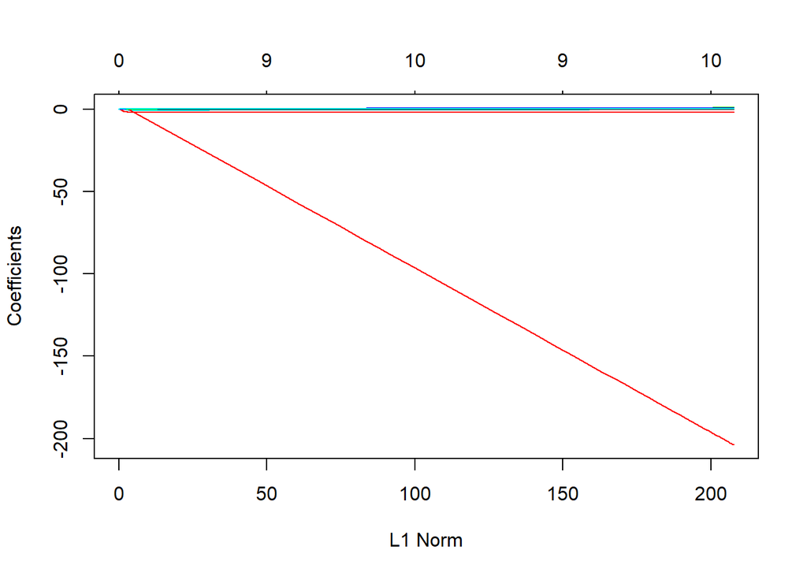

```r
# -1 to get rid of intercept that glmnet knows to include:
x_white = model.matrix(y_quality~., white)[,-1]
y_white = white[,'y_quality']
lasso_fit_white = glmnet(x_white, y_white, alpha=1)
plot(lasso_fit_white)
```

Looks similar to the first attempt at `red` `glmnet` plot - the influence of `density` (red diagonal line, again) overwhelms the details of the chart. It’s coefficient begins at an extreme value of -203.137, making me think something has gone wrong. Examine the stats on that column again, and output the straightforward multiple-regression model from early on:

```r
summary(white$density)
```

```
##    Min. 1st Qu.  Median    Mean 3rd Qu.    Max.
##  0.9871  0.9917  0.9937  0.9940  0.9961  1.0103
```

```r
summary(lm_white)
```

```
##
## Call:
## lm(formula = y_quality ~ ., data = white)
##
## Residuals:
##     Min      1Q  Median      3Q     Max
## -3.8682 -0.4947 -0.0426  0.4610  3.1089
##
## Coefficients:
##                           Estimate    Std. Error t value Pr(>|t|)
## (Intercept)           211.42439858   22.73663156   9.299  < 2e-16 ***
## fixed_acidity           0.11080834    0.02289106   4.841 1.33e-06 ***
## volatile_acidity       -1.87540353    0.11357002 -16.513  < 2e-16 ***
## citric_acid             0.02523004    0.09555961   0.264    0.792
## residual_sugar          0.10142218    0.00859641  11.798  < 2e-16 ***
## chlorides              -0.07989962    0.54645945  -0.146    0.884
## free_sulfur_dioxide     0.00346227    0.00084419   4.101 4.18e-05 ***
## total_sulfur_dioxide    0.00002594    0.00038285   0.068    0.946
## density              -212.19363813   23.03954920  -9.210  < 2e-16 ***
## pH                      0.86928298    0.11192723   7.767 9.76e-15 ***
## sulphates               0.70155445    0.10123569   6.930 4.76e-12 ***
## alcohol                 0.11861343    0.02882011   4.116 3.92e-05 ***
## ---
## Signif. codes:  0 '***' 0.001 '**' 0.01 '*' 0.05 '.' 0.1 ' ' 1
##
## Residual standard error: 0.7497 on 4885 degrees of freedom
## Multiple R-squared:  0.2852, Adjusted R-squared:  0.2836
## F-statistic: 177.2 on 11 and 4885 DF,  p-value: < 2.2e-16
```

And again, the stats don’t appear extreme in any way, the range between min and max appears pretty narrow. Contents of `lm_white` show the problem, assuming it is a problem, has been lying in relatively plain sight all along, I just didn’t notice the extreme coeff on `density`.  
Simple plot of `density` values reveals a potential outlier - I had removed a single observation early on, in Problem 1, but that’s it. I’m thinking perhaps a `log` or `sqrt` transformation on the data might have proved useful….

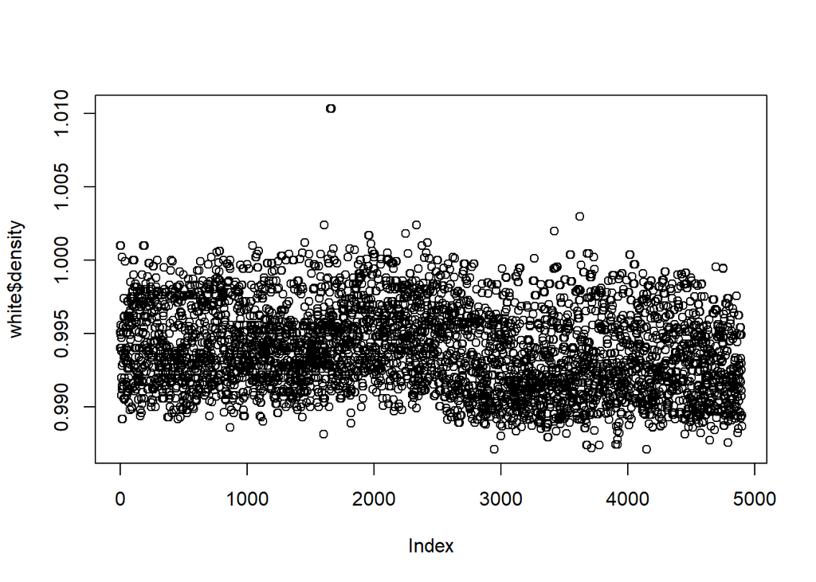

```r
plot(white$density)
```

Some sleuthing and find there that outlying data point at top of above chart is actually two data points, at rows 1654 and 1664 of the current `white` dataset. If those were removed the `density` values are much more tightly clustered.

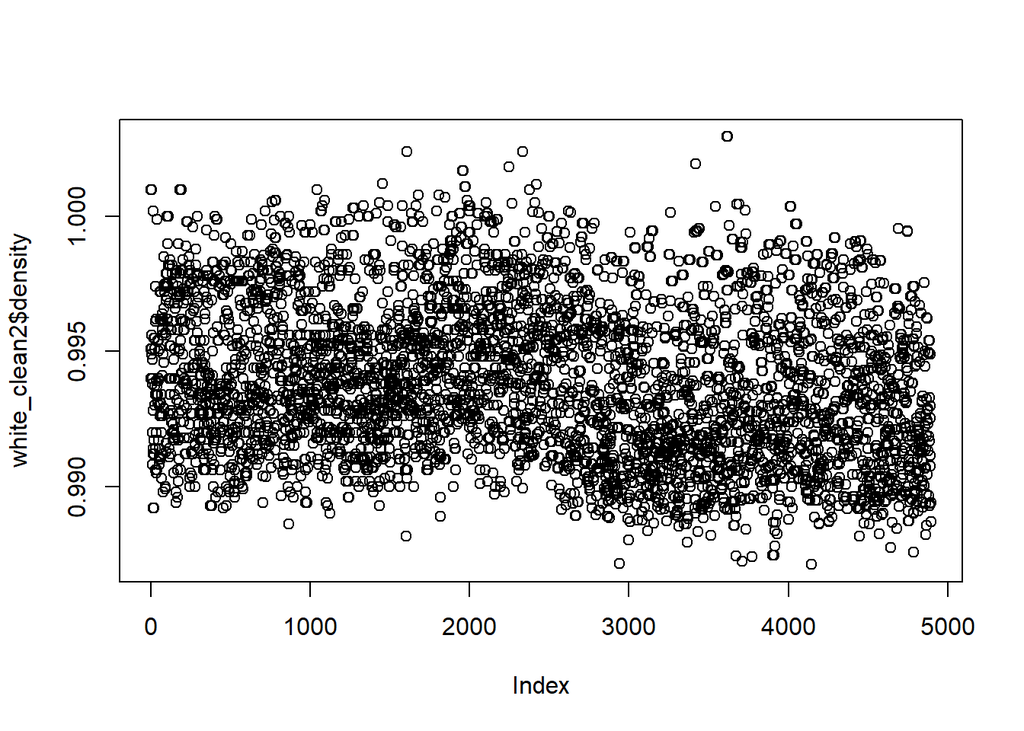

```r
# possible density outliers at row indices in current white dataset: 1654, 1664
#lm_white_raw_clean2 = lm(y_quality~., white[-2782,])
white_clean2 = white[-c(1654, 1664),]
plot(white_clean2$density)
```

In interests of further sanity check, do a new `lm` on all `y_quality`~all-variables of the `white` dataset w/o the two maybe-outliers, the one that produced above plot:

```r
lm_white2 = lm(y_quality~., white_clean2)
summary(lm_white2)
```

```
##
## Call:
## lm(formula = y_quality ~ ., data = white_clean2)
##
## Residuals:
##     Min      1Q  Median      3Q     Max
## -3.8799 -0.4957 -0.0420  0.4630  3.1111
##
## Coefficients:
##                           Estimate    Std. Error t value Pr(>|t|)
## (Intercept)           223.42317147   23.20659141   9.628  < 2e-16 ***
## fixed_acidity           0.11880846    0.02309387   5.145 2.79e-07 ***
## volatile_acidity       -1.87044750    0.11353405 -16.475  < 2e-16 ***
## citric_acid             0.03313051    0.09556547   0.347 0.728848
## residual_sugar          0.10501736    0.00870696  12.061  < 2e-16 ***
## chlorides              -0.04798689    0.54634952  -0.088 0.930014
## free_sulfur_dioxide     0.00342967    0.00084389   4.064 4.90e-05 ***
## total_sulfur_dioxide    0.00008363    0.00038333   0.218 0.827303
## density              -224.32084662   23.51328283  -9.540  < 2e-16 ***
## pH                      0.90319388    0.11266052   8.017 1.35e-15 ***
## sulphates               0.72148756    0.10148937   7.109 1.34e-12 ***
## alcohol                 0.10409598    0.02936219   3.545 0.000396 ***
## ---
## Signif. codes:  0 '***' 0.001 '**' 0.01 '*' 0.05 '.' 0.1 ' ' 1
##
## Residual standard error: 0.7493 on 4883 degrees of freedom
## Multiple R-squared:  0.2861, Adjusted R-squared:  0.2845
## F-statistic: 177.9 on 11 and 4883 DF,  p-value: < 2.2e-16
```

And `density` still has an extreme slope. I’m still suspicious I should have taken a different approach (transformation?) on the `white` dataset much earlier but what is done is done and I wouldn’t have sufficient time to re-do everything should I find something addressable. Onwards and upwards it is. (with the original `white` dataset minus only the one outlier I removed in Problem 1).

As with `red`, lets do a zoom in on the droppage of various variables as regularization increases.

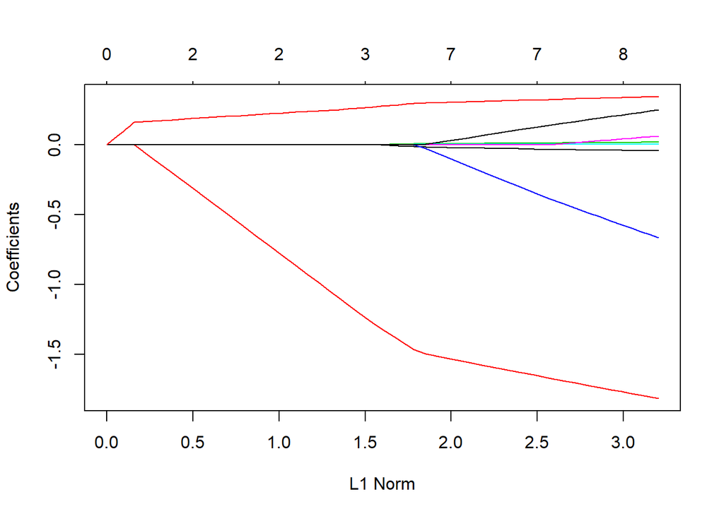

```r
rng = 10^((-70:0)/40)
#rng = seq(0.005, 0.014, length.out=100)
lasso_fit_white2 = glmnet(x_white, y_white, alpha=1, lambda=rng)
plot(lasso_fit_white2)
```

Next is the output of `cv.glmnet`, showing averages and variation in MSE values under cross-validation for select values of $\lambda$ (X axis is the log of the input $\lambda$ value):

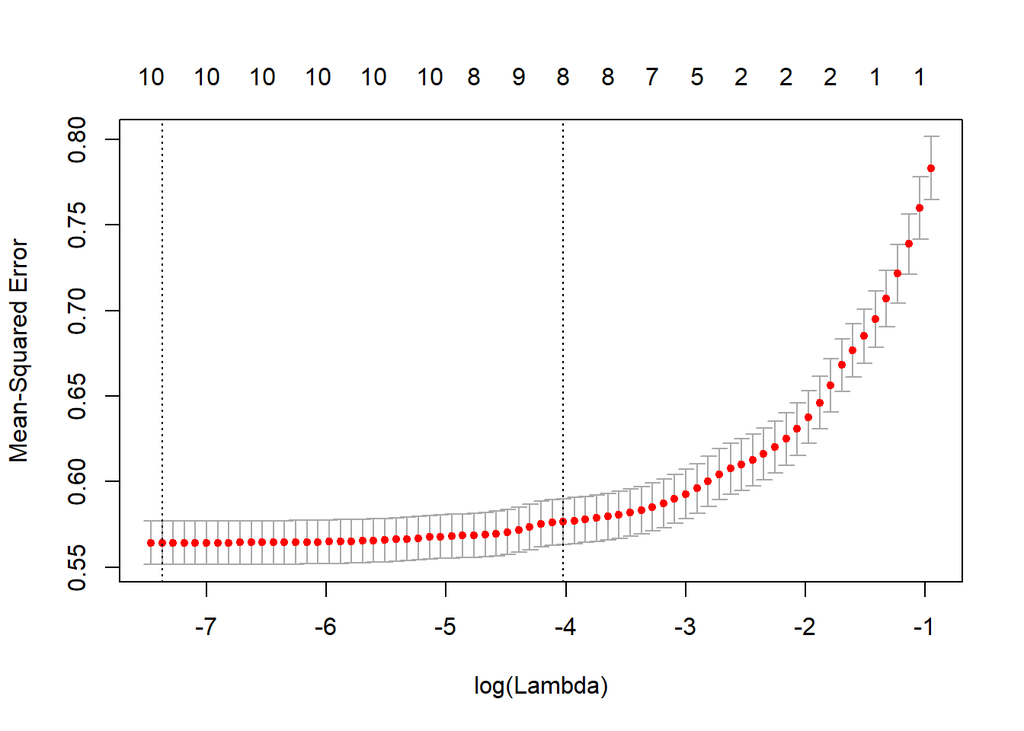

```r
cv_lasso_fit_white = cv.glmnet(x_white, y_white, alpha=1)
plot(cv_lasso_fit_white)
```

The two vertical lines above have previously been discussed. Details on the `lambda.min` and `lambda.1se` are below.

```r
lowest_mse_lambda_white = cv_lasso_fit_white$lambda.min
print(paste0('lambda producing lowest MSE for white wines/lasso: ', lowest_mse_lambda_white))
```

```
## [1] "lambda producing lowest MSE for white wines/lasso: 0.000628716020076965"
```

```r
print(paste0('log of same value, used for X axis in chart: ', log(lowest_mse_lambda_white)))
```

```
## [1] "log of same value, used for X axis in chart: -7.3718308816259"
```

```r
predict(lasso_fit_white, type="coefficients", s=lowest_mse_lambda_white)
```

```
## 12 x 1 sparse Matrix of class "dgCMatrix"
##                                   1
## (Intercept)           196.312527909
## fixed_acidity           0.097571379
## volatile_acidity       -1.877900314
## citric_acid             0.018139427
## residual_sugar          0.095635670
## chlorides              -0.134219123
## free_sulfur_dioxide     0.003473143
## total_sulfur_dioxide    .
## density              -196.828118424
## pH                      0.809447846
## sulphates               0.675879987
## alcohol                 0.135544129
```

```r
lowest_mse_plus_one_sd_lambda_white = cv_lasso_fit_white$lambda.1se
print(paste0('lambda producing MSE 1SD away from min, for white wines/lasso: ', lowest_mse_plus_one_sd_lambda_white))
```

```
## [1] "lambda producing MSE 1SD away from min, for white wines/lasso: 0.017906057762394"
```

```r
print(paste0('log of same value, used for X axis in chart: ', log(lowest_mse_plus_one_sd_lambda_white)))
```

```
## [1] "log of same value, used for X axis in chart: -4.02261620090729"
```

```r
predict(lasso_fit_white, type="coefficients", s=lowest_mse_plus_one_sd_lambda_white)
```

```
## 12 x 1 sparse Matrix of class "dgCMatrix"
##                                 1
## (Intercept)           2.564528799
## fixed_acidity        -0.043510694
## volatile_acidity     -1.814834747
## citric_acid           .
## residual_sugar        0.017960109
## chlorides            -0.663810945
## free_sulfur_dioxide   0.002828385
## total_sulfur_dioxide  .
## density               .
## pH                    0.061746632
## sulphates             0.247342506
## alcohol               0.343752847
```

Next analysis involves lasso on the `white` data combined with resampling, along with a check on model stability.

```r
# lasso_sampling defined in the red wine analysis
try_count=30
lasso_sampling_results_white = lasso_sampling(x_white, y_white, try_count=try_count)
resampling_mse_white = lasso_sampling_results_white[[1]]
lasso_coef_cnt_white = lasso_sampling_results_white[[2]]

print(paste0('MSE resampling, lasso: ', resampling_mse_white)) #around 0.44
```

```
## [1] "MSE resampling, lasso: 0.582076449255952"
```

```r
print(sprintf('Coefficient counts, across %d resample rounds:', try_count))
```

```
## [1] "Coefficient counts, across 30 resample rounds:"
```

```r
lasso_coef_cnt_white
```

```
##        fixed_acidity     volatile_acidity          citric_acid
##                   28                   30                    2
##       residual_sugar            chlorides  free_sulfur_dioxide
##                   30                   24                   28
## total_sulfur_dioxide              density                   pH
##                    2                    3                   12
##            sulphates              alcohol
##                   27                   30
```

Above returns an MSE of 0.5820764, which is almost as good as that from **Sub-problem3**, which was using a nvar=8 model and returned 0.5634881 via 10-fold cross-validation (5-fold produced about the same value).

Breakdown on the 30 rounds:  
* always, or almost always, keep: `volatile_acidity`, `alcohol`, `residual_sugar`, `free_sulfur_dioxide` `fixed_acidity`  
* always, or almost always, zero out: `citric_acid`, `total_sulfur_dioxide`, `density`  
* Usually keep: `sulphates`,`chlorides`  
* usually drop: `pH`

I’m going to guess an nvar of 6 or 7 is most commonly produced by above code, at least one fewer than I found optimal in earlier problem re section methods.

Lasso code on `white` complete, time to move on to ridge regression on same dataset.

### ridge regression, white wine

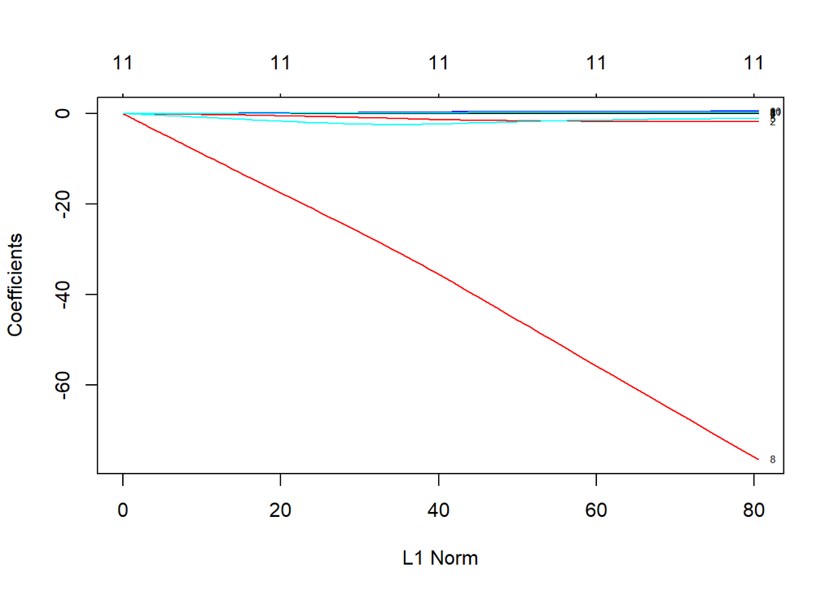

```r
ridge_fit_white = glmnet(x_white, y_white, alpha=0)
plot(ridge_fit_white, label=TRUE)
```

the `plot` results for `glmnet` display that `density` probelm once more.

Try again but limit y axis in order to zoom in, had tried similar in earlier section but inadvertantly caused the y-axis to rotate and swap signs, which confused me.

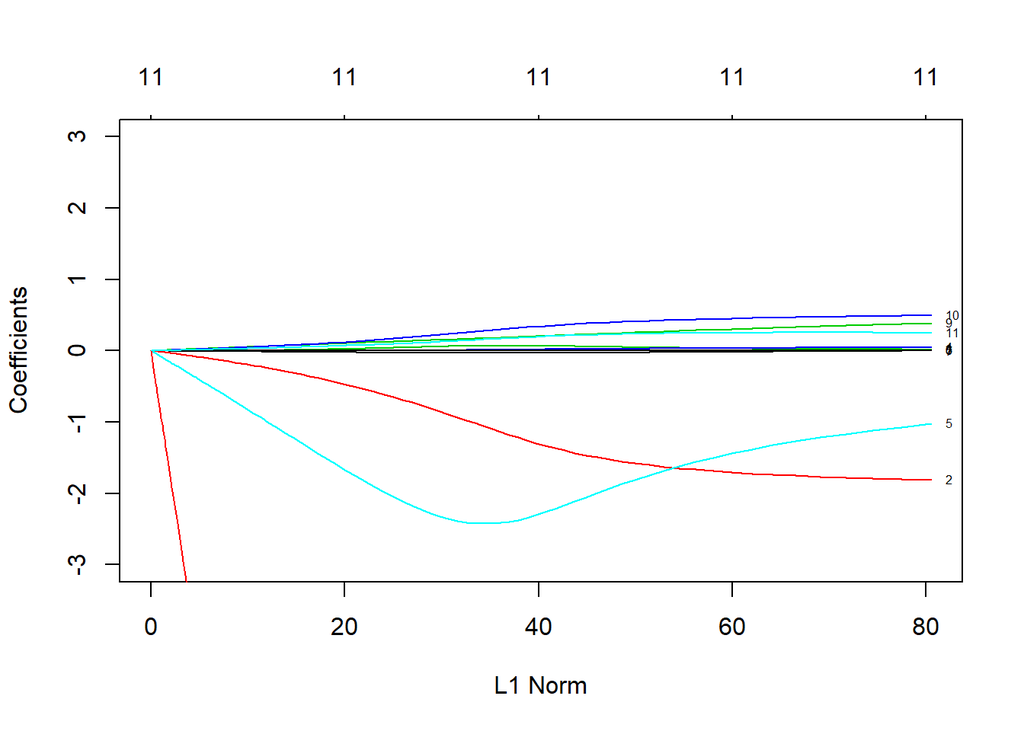

```r
ridge_fit_white = glmnet(x_white, y_white, alpha=0)
plot(ridge_fit_white, label=TRUE, ylim=c(-3, 3))
```

This plot looks better for what its worth. The majority of variables, those with positive coefficients, gradually converge towards zero. The two ones that are negative in above closeup, which I believe to be `volatile_acidity` and `chlorides` after looking at innards of the `glmnet` results, are more erratic.

As was done for `red`, run a `cv.glmnet` to perform cross-validation on the ridge regression model in order to choose optimal $\lambda$

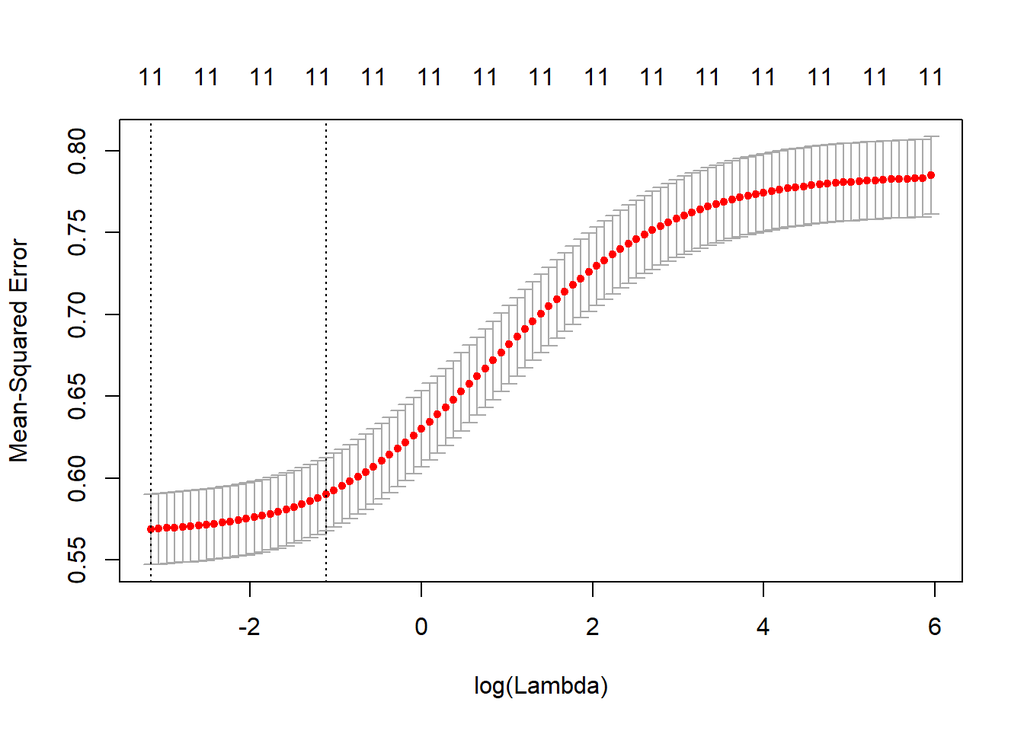

```r
cv_ridge_fit_white = cv.glmnet(x_white, y_white, alpha=0)
plot(cv_ridge_fit_white)
```

```r
lowest_mse_lambda_ridge_white = cv_ridge_fit_white$lambda.min
print(paste0('lambda producing lowest MSE for white wines/ridge: ', lowest_mse_lambda_ridge_white))
```

```
## [1] "lambda producing lowest MSE for white wines/ridge: 0.0423386840013977"
```

```r
p_lowest_mse_predict_ridge_white = predict(cv_ridge_fit_white, type="coefficients", s=lowest_mse_lambda_ridge_white)
p_lowest_mse_predict_ridge_white
```

```
## 12 x 1 sparse Matrix of class "dgCMatrix"
##                                   1
## (Intercept)           74.8926865157
## fixed_acidity          0.0002723008
## volatile_acidity      -1.7997368443
## citric_acid            0.0204993715
## residual_sugar         0.0468210577
## chlorides             -1.0703736434
## free_sulfur_dioxide    0.0042392588
## total_sulfur_dioxide  -0.0005783459
## density              -73.3793008914
## pH                     0.3745594786
## sulphates              0.4940236746
## alcohol                0.2531676811
```

```r
print('min MSE, variables absolute weighting, high to low:')
```

```
## [1] "min MSE, variables absolute weighting, high to low:"
```

```r
sort(abs(p_lowest_mse_predict_ridge_white[-1,1]), decreasing=TRUE)
```

```
##              density     volatile_acidity            chlorides
##        73.3793008914         1.7997368443         1.0703736434
##            sulphates                   pH              alcohol
##         0.4940236746         0.3745594786         0.2531676811
##       residual_sugar          citric_acid  free_sulfur_dioxide
##         0.0468210577         0.0204993715         0.0042392588
## total_sulfur_dioxide        fixed_acidity
##         0.0005783459         0.0002723008
```

```r
lowest_mse_plus_one_sd_lambda_ridge_white = cv_ridge_fit_white$lambda.1se
print(paste0('lambda producing MSE 1SD away from min, for white wines/ridge: ', lowest_mse_plus_one_sd_lambda_ridge_white))
```

```
## [1] "lambda producing MSE 1SD away from min, for white wines/ridge: 0.327813053947947"
```

```r
p_lowest_mse_1sd_predict_ridge_white = predict(cv_ridge_fit_white, type="coefficients", s=lowest_mse_plus_one_sd_lambda_ridge_white)
p_lowest_mse_1sd_predict_ridge_white
```

```
## 12 x 1 sparse Matrix of class "dgCMatrix"
##                                   1
## (Intercept)           38.6117786239
## fixed_acidity         -0.0317951294
## volatile_acidity      -1.2951025159
## citric_acid            0.0707208582
## residual_sugar         0.0180518972
## chlorides             -2.3064540908
## free_sulfur_dioxide    0.0034404182
## total_sulfur_dioxide  -0.0007918054
## density              -35.2734186560
## pH                     0.2018110926
## sulphates              0.3392092272
## alcohol                0.1951582842
```

```r
print('1 SD away, variables absolute weighting, high to low:')
```

```
## [1] "1 SD away, variables absolute weighting, high to low:"
```

```r
sort(abs(p_lowest_mse_1sd_predict_ridge_white[-1,1]), decreasing=TRUE)
```

```
##              density            chlorides     volatile_acidity
##        35.2734186560         2.3064540908         1.2951025159
##            sulphates                   pH              alcohol
##         0.3392092272         0.2018110926         0.1951582842
##          citric_acid        fixed_acidity       residual_sugar
##         0.0707208582         0.0317951294         0.0180518972
##  free_sulfur_dioxide total_sulfur_dioxide
##         0.0034404182         0.0007918054
```

```r
try_count = 30
ridge_sampling_results_white = ridge_sampling(x_white, y_white, try_count=try_count)
ridge_resampling_mse_white = ridge_sampling_results_white[[1]]
ridge_coef_cnt_white = ridge_sampling_results_white[[2]]

print(paste0('MSE resampling, ridge: ', ridge_resampling_mse_white))
```

```
## [1] "MSE resampling, ridge: 0.590447758647513"
```

```r
print(sprintf('Coefficient counts, across %d resample rounds:', try_count))
```

```
## [1] "Coefficient counts, across 30 resample rounds:"
```

```r
ridge_coef_cnt_white
```

```
##        fixed_acidity     volatile_acidity          citric_acid
##        -0.0276459845        -1.3804787245         0.0700421201
##       residual_sugar            chlorides  free_sulfur_dioxide
##         0.0217898544        -2.2096631384         0.0036814869
## total_sulfur_dioxide              density                   pH
##        -0.0008460008       -38.1901636960         0.2353979102
##            sulphates              alcohol
##         0.3584136618         0.2101287401
```

> Compare resulting models (in terms of number of variables and their effects) to those selected in the previous two tasks (by `regsubsets` and resampling), comment on differences and similarities among them.

`red` dataset:

From the above, **lasso** variable selection did not appear to be stable and best as I could interpret the most common nvar across multiple resampling trials was 4 or 5. The lowest MSE via resampling was 0.4459243

In **ridge**, of course all 11 predictors would always be persisted in the final model as none would ever technically hit zero, but 5 of those variables wound up with coefficients < 0.10, and of those, 2 were < 0.010, meaning the model was likely controlled by the 4 predictors with greatest weighting. The **ridge** resampling MSE was very close to that of **lasso**, 0.4513743

In **Sub-problem 2** I had this to say about `regsubsets` and results of exhaustive/forward/backward selection:

*all four searches came up with similar results. Looking at the indvidual metrics, and the variable count at which gains level off, I would say `rsq`, `adr2`, `cp` all agree on nvar=7, `rss` either 7 or 8, and `bic` at 6. All things considered here I think 7 would be a reasonable variable count to go with.*

The cross validation code (**Sub-problem 3**) was run for 5 and 10 fold:

- for 5-fold the lowest test MSE is at either nvar=6 or nvar=7
- for 10-fold, nvar=7 definitely appears to produce lowest mean test MSE, 0.4230298

Summary:  
The selection methods and cross-validation results more or less agreed on nvar=7 and the latter delivered the lowest test MSE. Regularization approaches both resulted in models with lower variable count (lower “effective” variable count in the case of **ridge**) and test MSE numbers that were a bit higher than cross-validation.

`white` dataset:

Within this current problem, for **lasso** the $\lambda$ producing lowest MSE only dropped one variable but using the `lambda` value resulted in a model dropping three variables. Details on this latter nvar=8 model led me to believe it would be more robust. The resampling exercise delivered an MSE of 0.5820764.

The **ridge** had similar results was with `red` actually: 5 variables < 0.10, with 2 of those being < 0.010. The nvar could be thought of as 6 perhaps, since that is how many would have had a significant effect.  
Resampling MSE for **ridge** was 0.5904478, my estimate had been that the resampling methods most often produced models with nvar of 6 or 7.

The `regsubsets` results from **Problem 2** agreed on nvar=8 for the three relevant search methods. For both `white`, and with the earlier `red`, variable selection was stable across the search methods - same set of predictors was chosen at the “best” nvar counts.

Under cross validation, both 5-fold and 10-fold experiments clearly indicated nvar=8 was best. Test MSE for the 10-fold was 0.5634881.

Summary:  
Test MSE numbers overall for `white` were higher than for `red`, quality for white wines appears to be more difficult to predict given these predictors. That being said, cross-validation also delivered the lowest test MSE, while that of regularization methods was a bit higher and almost indistinguishable from one another. There was greater agreement here, vs. `red`, in terms of optimal variable count. Subset selection methods, cross-validation (both 5-fold and 10-fold), and **lasso** all indicated nvar=8 would be best. Results for **ridge** are more difficult to categorize, but I’m estimating there were 6 variables in the final model, with associated resampling indicating 6 or 7 variables gave best results.

# Sub-problem 5: PCA (10 points)

Merge data for red and white wine (function `rbind` allows merging of two matrices/data frames with the same number of columns) and plot data projection to the first two principal components (e.g. biplot or similar plots). Does this representation suggest presence of clustering structure in the data? Does wine type (i.e. red or white) or quality appear to be associated with different regions occupied by observations in the plot? Please remember *not* to include quality attribute or wine type (red or white) indicator in your merged data, otherwise, apparent association of quality or wine type with PCA layout will be influenced by presence of those indicators in your data.

> Merge data for red and white wine (function `rbind` allows merging of two matrices/data frames with the same number of columns) and plot data projection to the first two principal components (e.g. biplot or similar plots).

Combine the datasets. I plan on scaling the data but first going to run out some summary statistics to support wisdom of such:

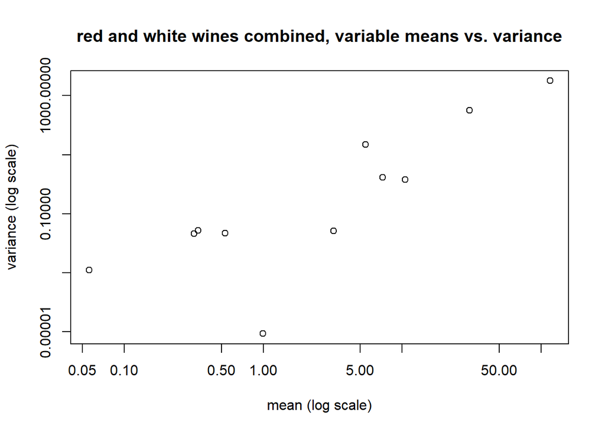

```r
# leave out y_quality, column 12
data = rbind(red[,-12], white[,-12])
data_mean = apply(data, 2, mean)
data_var = apply(data, 2, var)

plot(data_mean, data_var, log='xy',
     xlab='mean (log scale)', ylab='variance (log scale)',
     main='red and white wines combined, variable means vs. variance')
```

```r
print('Two attributes with highest mean, followed by two with highest variance')
```

```
## [1] "Two attributes with highest mean, followed by two with highest variance"
```

```r
format(data_mean[order(abs(data_mean), decreasing=TRUE)][1:2], scientific=FALSE)
```

```
## total_sulfur_dioxide  free_sulfur_dioxide
##          "115.73776"          " 30.52879"
```

```r
format(data_var[order(data_var, decreasing=TRUE)][1:2], scientific=FALSE)
```

```
## total_sulfur_dioxide  free_sulfur_dioxide
##          "3194.9103"          " 315.0116"
```

```r
print('Two attributes with lowest mean, followed by two with lowest variance')
```

```
## [1] "Two attributes with lowest mean, followed by two with lowest variance"
```

```r
format(data_mean[order(abs(data_mean), decreasing=FALSE)][1:2], scientific=FALSE)
```

```
##   chlorides citric_acid
## "0.0560311" "0.3185899"
```

```r
format(data_var[order(data_var, decreasing=FALSE)][1:2], scientific=FALSE)
```

```
##          density        chlorides
## "0.000008691451" "0.001227492489"
```

Previously we’ve seen a different variables being marked as more (or less) important in `red` and/or `white`, don’t want any predictors crowding out others (or being crowded out) simply because the scale on which they were measured. The `winequality.names` file doesn’include indications of measurement units but simply reviewing the above output gives off enough warning signs that scaling the data is a good idea.

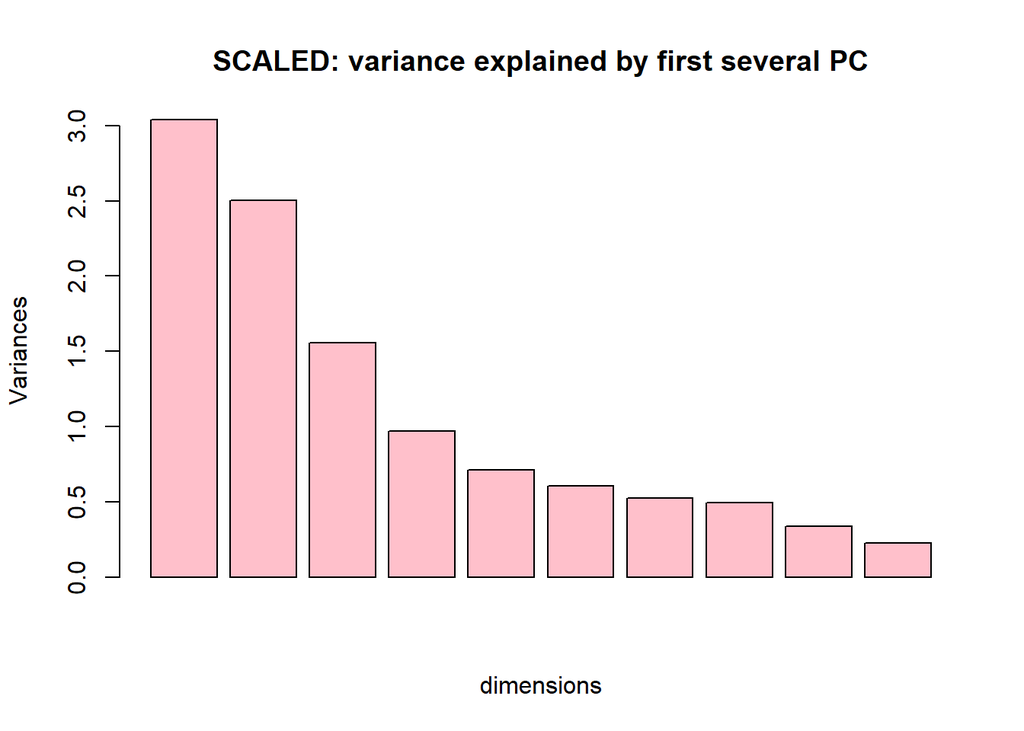

```r
pr_scaled = prcomp(data, scale=TRUE)
plot(pr_scaled, xlab='dimensions', main='SCALED: variance explained by first several PC', col='pink')
```

A scree plot of PCA results indicate that there are *not* one or two variables that overwhelmingly dominate amount of explained variance. The first two components may form a majority of explained variance but the drop from 1 to 2 and 2 to 3 is not extreme.

Full loadings for the 1st and 2nd principal components:

```r
pr_scaled$rotation[,1:2]
```

```
##                              PC1         PC2
## fixed_acidity        -0.23751804  0.33771556
## volatile_acidity     -0.38025715  0.11615738
## citric_acid           0.15230074  0.18062448
## residual_sugar        0.35095915  0.32359388
## chlorides            -0.28860392  0.31666929
## free_sulfur_dioxide   0.43027432  0.07185886
## total_sulfur_dioxide  0.48660939  0.08512709
## density              -0.04431198  0.58469407
## pH                   -0.21893851 -0.15578112
## sulphates            -0.29307477  0.19216395
## alcohol              -0.10777052 -0.46836504
```

The the largest loadings for the first and second PC respectively are:

```r
sort(abs(pr_scaled$rotation[,1]), decreasing=TRUE)[1]
```

```
## total_sulfur_dioxide
##            0.4866094
```

```r
sort(abs(pr_scaled$rotation[,2]), decreasing=TRUE)[1]
```

```
##   density
## 0.5846941
```

A `biplot` of the first two PC components of combined dataset:

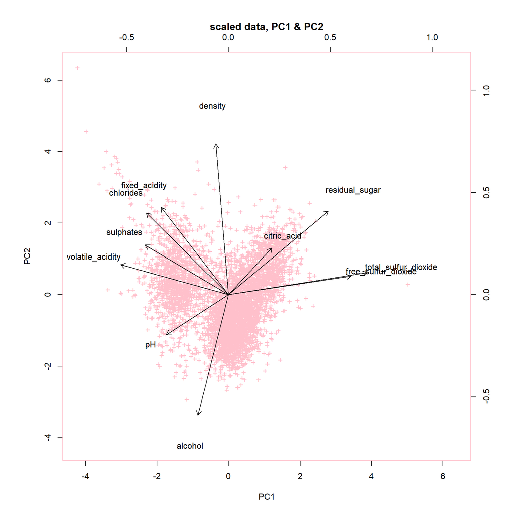

```r
biplot(pr_scaled, pc.biplot=TRUE, main='scaled data, PC1 & PC2', xlabs=rep('+', dim(pr_scaled$x)[1]), col=c('pink','black') )
```

I tried for a good while to come up with a chart that combined the PCA loadings from above with data points colored according to which dataset the originated from. I wasn’t able to come up with a solution in a reasonable amount of time so I’ve chosen to go with a separate chart that can be combined by eye with the above.

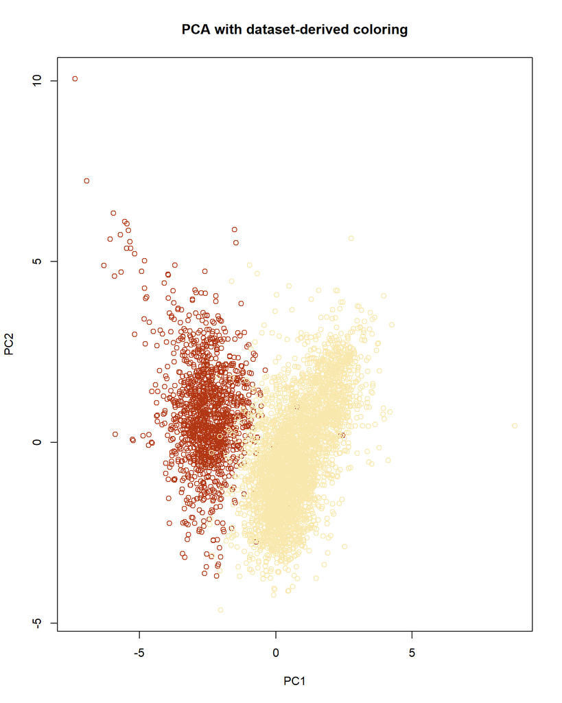

```r
row_idx = as.numeric(rownames(data.frame(pr_scaled$x)))
plot(pr_scaled$x[,1:2], main='PCA with dataset-derived coloring', col=c(ifelse(row_idx <= dim(red)[1], red_col, white_col)))
```

> Does this representation suggest presence of clustering structure in the data? Does wine type (i.e. red or white) or quality appear to be associated with different regions occupied by observations in the plot? Please remember *not* to include quality attribute or wine type (red or white) indicator in your merged data, otherwise, apparent association of quality or wine type with PCA layout will be influenced by presence of those indicators in your data.

Yes, there are two primary clusters of wine type per above chart, one elongated `white` wine cluster on the right, higher on x-axis than it is wide on y-axis and then another of the `red` wines on the left, also somewhat oval-shaped. The `red` cluster is less dense and more spread out but that appearance may at least partially due to there being 1/3 the number of `red` observations as `white`.

Below is same as earlier chart but broken into separate plots - I was troubleshooting some issues with my initial coloring (numerical filtering being foiled by underlying character data types) and below helped figure things out.

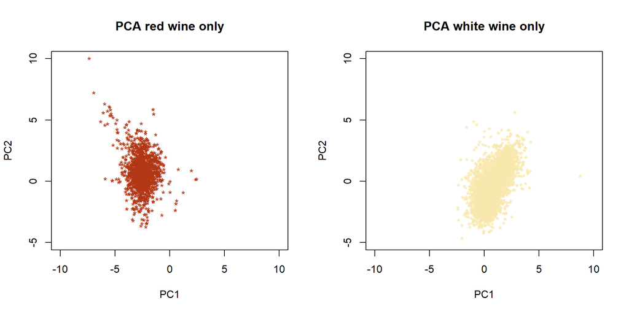

```r
oldPar <- par(mfrow=c(1,2))
plot(pr_scaled$x[1:dim(red)[1], 1:2], main='PCA red wine only', col=red_col, xlim=c(-10,10), ylim=c(-5,10), pch='*')
plot(pr_scaled$x[(dim(red)[1]+1):dim(pr_scaled$x)[1], 1:2], main='PCA white wine only', col=white_col, xlim=c(-10,10), ylim=c(-5,10), pch='*')
```

I’ll provide one attempt at plotting PCA and quality. Below any observations with `y_quality` <= 4 get colored as black, scores of 5 or 6 become violet and anything >= 7 is displayed as purple. I’ll note that more purple points are towards the middle bottom, which is an area the PC loadings had indicated meant a higher level of `alcohol`, so that kind of circles back to the very beginning of this problem set. Also, not surprising that the two most extreme points wind up in the “poor” bin.

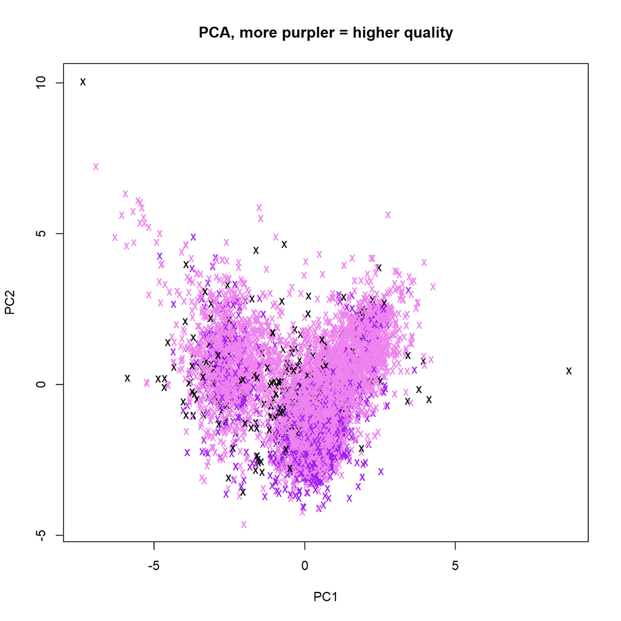

```r
wine_full = rbind(red, white)

wine_binner = function(x){ifelse(x<5, 1, ifelse(x<8, 2, 3))}
q_colors = c(rep('black', 4), rep('violet',2), rep('purple',3))

pc_q = cbind(pr_scaled$x[,1:2], wine_full$y_quality)
plot(pc_q[,1:2], main='PCA, more purpler = higher quality', col=q_colors[pc_q[,3]], pch='x')
```

```r
#plot(pr_scaled$x[,1:2], main='PCA with dataset-derived coloring', col=c(ifelse(row_idx <= dim(red)[1], red_col, white_col)))
```

# Extra 10 points: model wine quality using principal components

Compute PCA representation of the data for one of the wine types (red or white) *excluding wine quality attribute* (of course!). Use resulting principal components (slot `x` in the output of `prcomp`) as new predictors to fit a linear model of wine quality as a function of these predictors. Compare resulting fit (in terms of MSE, r-squared, etc.) to those obtained above. Comment on the differences and similarities between these fits.